# Practical Machine Learning Assignment

MinShen

21 Dec 2015

### Background

Using devices such as Jawbone Up, Nike FuelBand, and Fitbit it is now possible to collect a large amount of data about personal activity relatively inexpensively. These type of devices are part of the quantified self movement - a group of enthusiasts who take measurements about themselves regularly to improve their health, to find patterns in their behavior, or because they are tech geeks. One thing that people regularly do is quantify how much of a particular activity they do, but they rarely quantify how well they do it. In this project, your goal will be to use data from accelerometers on the belt, forearm, arm, and dumbell of 6 participants. They were asked to perform barbell lifts correctly and incorrectly in 5 different ways. More information is available from the website here: http://groupware.les.inf.puc-rio.br/har (see the section on the Weight Lifting Exercise Dataset).

### Data Sources

The training data for this project are available here:

https://d396qusza40orc.cloudfront.net/predmachlearn/pml-training.csv

The test data are available here:

https://d396qusza40orc.cloudfront.net/predmachlearn/pml-testing.csv

### Load Required Library

```r
library(caret)
library(randomForest)
set.seed(2048)
options(warn=-1)
```

### Loading Data

Loading the required libraries and reading in the training and testing datasets, assigning missing values to entries that are currently ‘NA’ or blank.

```r
trainingOrg = read.csv("./data/pml-training.csv", na.strings=c("", "NA", "NULL"))

testingOrg = read.csv("./data/pml-testing.csv", na.strings=c("", "NA", "NULL"))

dim(trainingOrg)
```

```
## [1] 19622   160
```

```r
dim(testingOrg)
```

```
## [1]  20 160
```

### Reducing the number of predictors

```r
    # Remove variables that we believe have too many NA values.
    training.dena <- trainingOrg[ , colSums(is.na(trainingOrg)) == 0]
    dim(training.dena)
```

```
## [1] 19622    60
```

```r
    # Remove unrelevant variables There are some unrelevant variables that can be removed as they are unlikely to be related to dependent variable.
    remove = c('X', 'user_name', 'raw_timestamp_part_1', 'raw_timestamp_part_2', 'cvtd_timestamp', 'new_window', 'num_window')
    training.dere <- training.dena[, -which(names(training.dena) %in% remove)]
    dim(training.dere)
```

```
## [1] 19622    53
```

```r
    # only numeric variabls can be evaluated in this way.
    zeroVar= nearZeroVar(training.dere[sapply(training.dere, is.numeric)], saveMetrics = TRUE)
    training.nonzerovar = training.dere[,zeroVar[, 'nzv']==0]
    dim(training.nonzerovar)
```

```
## [1] 19622    53
```

```r
    # Remove highly correlated variables 90% (using for example findCorrelation() )
    # only numeric variabls can be evaluated in this way.
    corrMatrix <- cor(na.omit(training.nonzerovar[sapply(training.nonzerovar, is.numeric)]))
    dim(corrMatrix)
```

```
## [1] 52 52
```

```r
    # there are 52 variables.
    corrDF <- expand.grid(row = 1:52, col = 1:52)
    corrDF$correlation <- as.vector(corrMatrix)

    removecor = findCorrelation(corrMatrix, cutoff = .90, verbose = TRUE)
```

```
## Compare row 10  and column  1 with corr  0.992
##   Means:  0.27 vs 0.168 so flagging column 10
## Compare row 1  and column  9 with corr  0.925
##   Means:  0.25 vs 0.164 so flagging column 1
## Compare row 9  and column  4 with corr  0.928
##   Means:  0.233 vs 0.161 so flagging column 9
## Compare row 8  and column  2 with corr  0.966
##   Means:  0.245 vs 0.157 so flagging column 8
## Compare row 19  and column  18 with corr  0.918
##   Means:  0.091 vs 0.158 so flagging column 18
## Compare row 46  and column  31 with corr  0.914
##   Means:  0.101 vs 0.161 so flagging column 31
## Compare row 46  and column  33 with corr  0.933
##   Means:  0.083 vs 0.164 so flagging column 33
## All correlations <= 0.9
```

```r
    training.decor = training.nonzerovar[,-removecor]
    dim(training.decor)
```

```
## [1] 19622    46
```

We get 19622 samples and 46 variables.

### Split data to training and testing for cross validation.

```r
   inTrain <- createDataPartition(y=training.decor$classe, p=0.7, list=FALSE)
    training <- training.decor[inTrain,]; testing <- training.decor[-inTrain,]
    dim(training);dim(testing)
```

```
## [1] 13737    46
```

```
## [1] 5885   46
```

We got 13737 samples and 46 variables for training, 5885 samples and 46 variables for testing.

## Using Random Forests Model

Random forests build lots of bushy trees, and then average them to reduce the variance.

```r
   set.seed(12345)

    rf.training=randomForest(classe~.,data=training,ntree=100, importance=TRUE)
    rf.training
```

```
##
## Call:
##  randomForest(formula = classe ~ ., data = training, ntree = 100,      importance = TRUE)
##                Type of random forest: classification
##                      Number of trees: 100
## No. of variables tried at each split: 6
##
##         OOB estimate of  error rate: 0.72%
## Confusion matrix:
##      A    B    C    D    E  class.error
## A 3903    2    0    1    0 0.0007680492
## B   14 2628   14    0    2 0.0112866817
## C    0   20 2371    5    0 0.0104340568
## D    0    0   30 2220    2 0.0142095915
## E    0    1    1    7 2516 0.0035643564
```

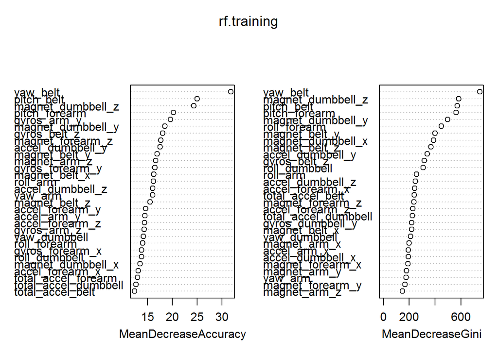

```r
    varImpPlot(rf.training,)
```

we can see which variables have higher impact on the prediction.

### Out-of Sample Accuracy

Our Random Forest model shows OOB estimate of error rate: 0.72% for the training data. Now we will predict it for out-of sample accuracy.

Now lets evaluate this tree on the test data.

```r
    tree.pred=predict(rf.training,testing,type="class")
    predMatrix = with(testing,table(tree.pred,classe))
    sum(diag(predMatrix))/sum(as.vector(predMatrix)) # error rate
```

```
## [1] 0.9952421
```

### Conclusion and Test Data Submit

As can be seen from the confusion matrix this random forest model is very accurate.

```r
    pml_write_files = function(x){
      n = length(x)
      for(i in 1:n){
        filename = paste0("problem_id_",i,".txt")
        write.table(x[i],file=filename,quote=FALSE,row.names=FALSE,col.names=FALSE)
      }
    }

    answers <- predict(rf.training, testingOrg)
    answers
```

```
##  1  2  3  4  5  6  7  8  9 10 11 12 13 14 15 16 17 18 19 20
##  B  A  B  A  A  E  D  B  A  A  B  C  B  A  E  E  A  B  B  B
## Levels: A B C D E
```

```r
    pml_write_files(answers)
```